# Minimal example: data without prey replacement

```r
rm(list=ls())
library(BayesFR)
```

This dataset is originally from [Hossie and Murray (2010)](https://doi.org/10.1007/s00442-010-1568-6) and was made available in the FoRAGE database [(Uiterwaal et al. 2022)](https://doi.org/10.5063/F1RX99KB). It includes data for a dragonfly nymph predator feeding on tadpoles in three leaf litter treatments. Here, we will regress number of eaten prey $N_E$ against initial prey abundance $N_0$. All experiments were run for 24 hours and eaten prey were not replaced. We are using the high leaf litter treatment.

```r
data(df_Hossie_and_Murray_2010_OECOLOGIA)
df = subset(df_Hossie_and_Murray_2010_OECOLOGIA, ID=="Figure 1e")
head(df)
```

```
   N0 NE Time    Predator         Prey        ID
63  5  1   24 Anax junius Rana pipiens Figure 1e
64  5  3   24 Anax junius Rana pipiens Figure 1e
65  5  4   24 Anax junius Rana pipiens Figure 1e
66 10  7   24 Anax junius Rana pipiens Figure 1e
67 10  9   24 Anax junius Rana pipiens Figure 1e
68 10 10   24 Anax junius Rana pipiens Figure 1e
```

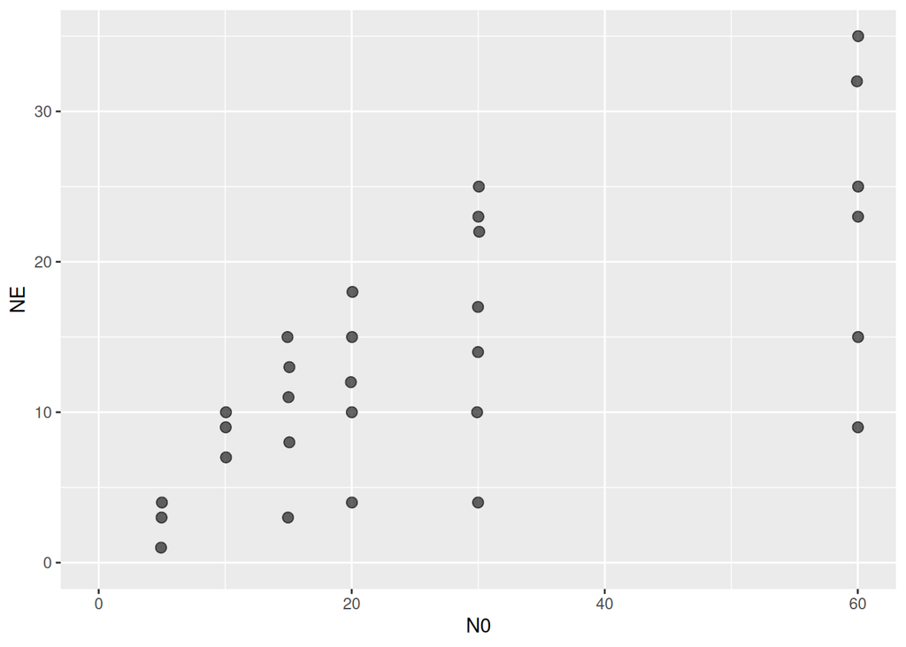

```r
ggplot(aes(N0,NE), data=df) +
  geom_jitter(width=0.1, height=0.0, alpha=0.6, size=2.5) +
  coord_cartesian(xlim=c(0,NA), ylim=c(0,NA))
```

We intend to estimate a type 3 functional response, which has a density-dependent attack rate $a=bN$, and is parameterized with attack rate coeffient $b$ and handling time $h$. Since eaten prey were not replaced (and number of available prey is not constant), we cannot directly fit the type 3 functional response
$$F(N) = \frac{bN^2}{1+bhN^2}PT$$
to the observed data. Instead, prey abundance is modeled dynamically by the differential equation
$$\frac{dN}{dt} = -\frac{bN^2}{1+bhN^2}P, \quad N(t=0)=N_0$$
With its solution in the interval $t=[0,T]$, the final number of prey $N(t=T)=N_T$ is used to compute predictions $\hat{N}_E=N_0-N_T$. Analytical solutions exist for the type 2 FR (LambertW formula) and the type 3 FR (quadratic equation), which are used in this package. For other functional responses, such as the generalized type 3 FR with a flexible exponent $q$, a numerical solution of the corresponding differential equation is implemented. An alternative parameterization $\frac{f_\max N^2}{N_\text{half}^2+N^2}$ using maximum feeding rate and half-saturation density is presented in the priors tutorial.

Then, we still need to define a likelihood function for model fitting. Observed numbers of eaten prey are integers bounded between $0$ and $N_0$, because the predator cannot eat more than the initial abundance. This makes the Binomial distribution
$$N_E\sim\text{Binomial}\left(n,\ p\right)$$
with $n=N_0$ trials and individual prey probability of being eaten $p=\frac{N_0-N_T}{N_0}$ an obvious choice. Alternatively, the Beta Binomial distribution for overdispersed data is discussed in the tutorial on likelihood functions.

The dynamical prediction model is defined by the function `Type3H_dyn()` and coded in `Type3H_dyn_code` (which is used later in the brms call). It computes number of eaten prey based on these arguments: abundance of offered prey `N0`, predator abundance `P0`, experimental duration `Time`, and parameters `b` and `h`, in that exact order. We define the brms formula:

```r
FR.formula = bf( NE | trials(N0) ~ Type3H_dyn(N0,1.0,1.0,b,h)/N0,
                 b~1, h~1,
                 nl = TRUE)
```

For the Binomial distribution, the number of trials `N0` is specified, and the success probability must be computed by dividing predicted number of eaten `Type3H_dyn()` by number of trials `N0`. Here, we provided fixed values for `P0=1.0` and `Time=1.0` [day], which means parameters are also estimated in [day].

As in the previous example, we choose some very weakly informative priors, the lower boundary `lb=0` is required to keep parameters non-negative.

```r
FR.priors  = c(prior(exponential(1.0), nlpar="b", lb=0),
               prior(exponential(1.0), nlpar="h", lb=0)
)
```

We fit the model calling `brm()` with the model formula. The Binomial distribution is specified in `family` with the identity link, overwriting the default logit link (which is not required here because success probabilities are already bounded between 0 and 1). `stanvars` contains this package’s code for the prediction model `Type3H_dyn_code`. After the model is run, this function is made available to R via `expose_functions()`, which is required for computing model predictions.

```r
fit.1 = brm(FR.formula,
            family   = binomial(link="identity"),
            prior    = FR.priors,
            data     = df,
            cores    = 4,
            stanvars = stanvar(scode=Type3H_dyn_code, block="functions")
)
expose_functions(fit.1, vectorize=TRUE)
```

We check the summary table and the traceplots for MCMC convergence (`Rhat` values <1.01 and good mixing of the chains):

```r
summary(fit.1)
```

```
 Family: binomial
  Links: mu = identity
Formula: NE | trials(N0) ~ Type3H_dyn(N0, 1, 1, b, h)/N0
         b ~ 1
         h ~ 1
   Data: df (Number of observations: 29)
  Draws: 4 chains, each with iter = 2000; warmup = 1000; thin = 1;
         total post-warmup draws = 4000

Regression Coefficients:
            Estimate Est.Error l-95% CI u-95% CI Rhat Bulk_ESS Tail_ESS
b_Intercept     0.26      0.06     0.17     0.40 1.00     1449     1996
h_Intercept     0.05      0.00     0.04     0.05 1.00     1409     1861

Draws were sampled using sampling(NUTS). For each parameter, Bulk_ESS
and Tail_ESS are effective sample size measures, and Rhat is the potential
scale reduction factor on split chains (at convergence, Rhat = 1).
```

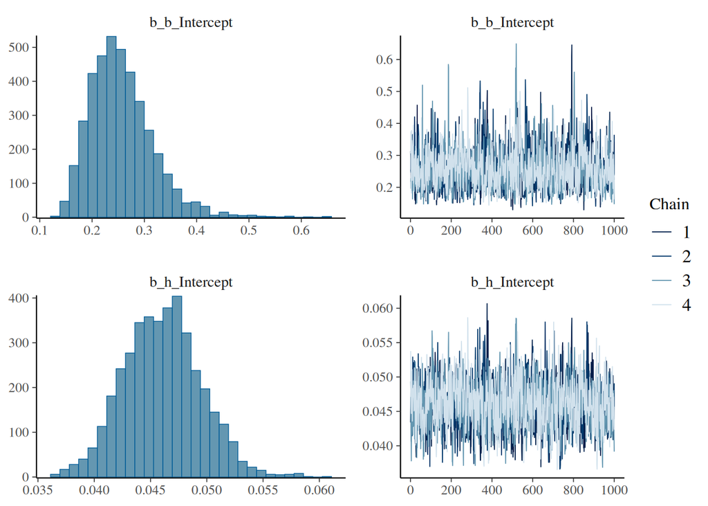

```r
plot(fit.1)
```

Finally, we plot model predictions against the observed data with `conditional_effects()`. This function uses samples from the parameters’ posterior distribution to compute posterior predictions of fitted values, which are displayed as mean fitted value (in blue) and 95% credible intervals (gray).

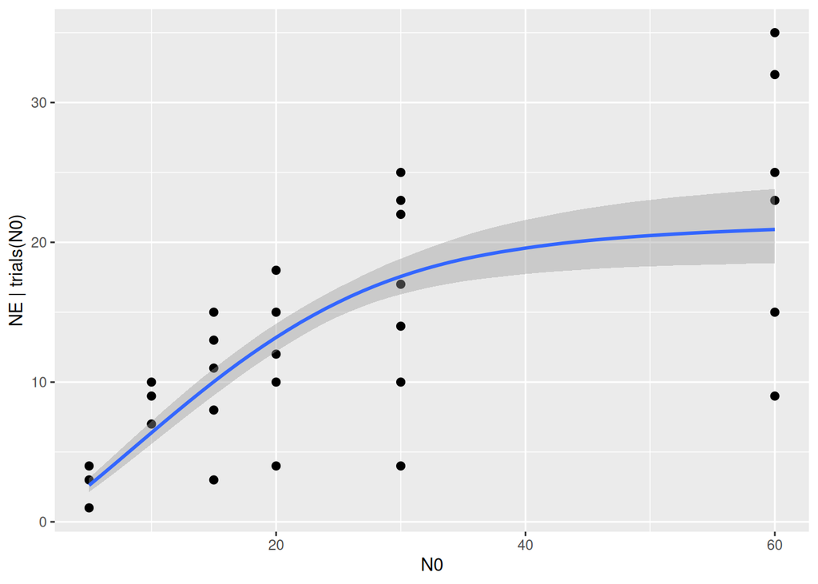

```r
plot(conditional_effects(fit.1), points=TRUE)
```

The plot can be modified to show the sigmoidal shape of the type 3 FR at low abundances. For a fully customizable plot, the output can also be saved in a ggplot object with `p = conditional_effects()`.

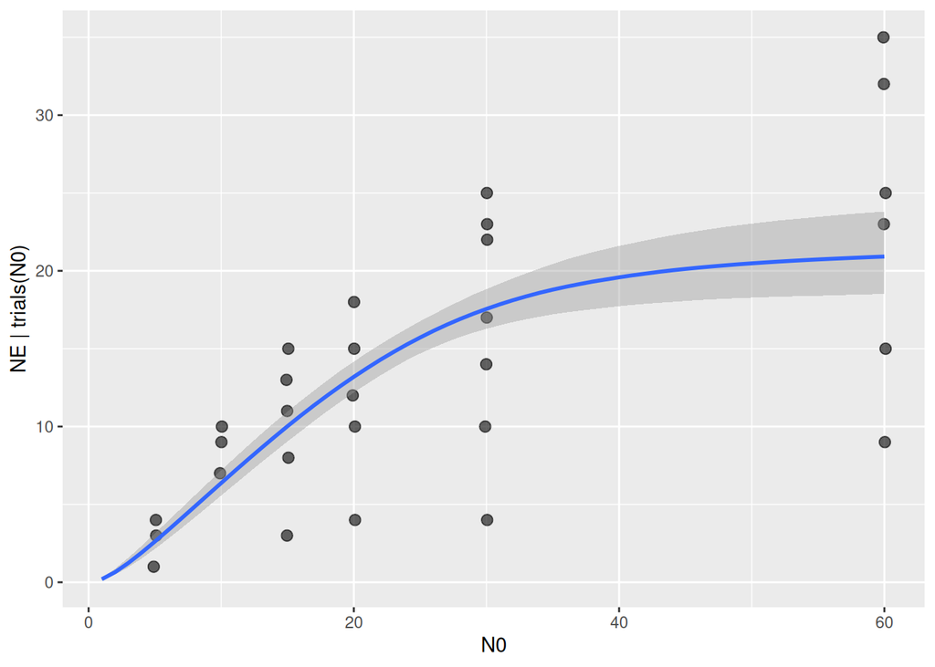

```r
plot(conditional_effects(fit.1,
                         effects="N0",
                         int_conditions=data.frame(N0=1:60)),
     points=TRUE, point_args=list(width=0.1, alpha=0.6, size=2.5))
```